# Practice-6

Harsh

29/06/2020

```r
#Importing all libraries required

#install.packages("rpart")
#install.packages("rpart.plot")

library(psych)
library(caret)
library(rpart)
library(rpart.plot)
library(RWeka)
```

Problem 1: Download the data set on student achievement in secondary education math education of two Portuguese schools (use the data set Students Math).

1. Create scatter plots and pairwise correlations between age, absences, G1, and G2 and final grade (G3) using the pairs.panels() function in R.
2. Build a multiple regression model predicting final math grade (G3) using as many features as you like but you must use at least four. Include at least one categorical variables and be sure to properly convert it to dummy codes. Select the features that you believe are useful – you do not have to include all features.
3. Using the model from (2), use stepwise backward elimination to remove all non-significant variables and then state the final model as an equation. State the backward elimination measure you applied (p-value, AIC, Adjusted R2). This tutorial shows how to use various feature elimination techniques.
4. Calculate the 95% confidence interval for a prediction – you may choose any data you wish for some new student.
5. What is the RMSE for this model – use the entire data set for both training and validation. You may find the residuals() function useful. Alternatively, you can inspect the model object, e.g., if your model is in the variable m, then the residuals (errors) are in m$residuals and your predicted values (fitted values) are in m$fitted.values.

```r
#Importing student Data
student_math <- read.csv("C:\\Users\\harsh\\Desktop\\Introduction to Machine learning and Data Mining\\Practice 6\\student-mat.csv",header = TRUE, sep = ';')

#Exploring Data
head(student_math)
```

|  | school | sex | age | address | famsize | Pstatus | Medu | Fedu | Mjob | Fjob | reason | guardian | traveltime | studytime | failures | schoolsup | famsup | paid | activities | nursery | higher | internet | romantic | famrel | freetime | goout | Dalc | Walc | health | … |
| --- | --- | --- | --- | --- | --- | --- | --- | --- | --- | --- | --- | --- | --- | --- | --- | --- | --- | --- | --- | --- | --- | --- | --- | --- | --- | --- | --- | --- | --- | --- |
| 1 | GP | F | 18 | U | GT3 | A | 4 | 4 | at_home | teacher | course | mother | 2 | 2 | 0 | yes | no | no | no | yes | yes | no | no | 4 | 3 | 4 | 1 | 1 | 3 | … |
| 2 | GP | F | 17 | U | GT3 | T | 1 | 1 | at_home | other | course | father | 1 | 2 | 0 | no | yes | no | no | no | yes | yes | no | 5 | 3 | 3 | 1 | 1 | 3 | … |
| 3 | GP | F | 15 | U | LE3 | T | 1 | 1 | at_home | other | other | mother | 1 | 2 | 3 | yes | no | yes | no | yes | yes | yes | no | 4 | 3 | 2 | 2 | 3 | 3 | … |
| 4 | GP | F | 15 | U | GT3 | T | 4 | 2 | health | services | home | mother | 1 | 3 | 0 | no | yes | yes | yes | yes | yes | yes | yes | 3 | 2 | 2 | 1 | 1 | 5 | … |
| 5 | GP | F | 16 | U | GT3 | T | 3 | 3 | other | other | home | father | 1 | 2 | 0 | no | yes | yes | no | yes | yes | no | no | 4 | 3 | 2 | 1 | 2 | 5 | … |
| 6 | GP | M | 16 | U | LE3 | T | 4 | 3 | services | other | reputation | mother | 1 | 2 | 0 | no | yes | yes | yes | yes | yes | yes | no | 5 | 4 | 2 | 1 | 2 | 5 | … |

```r
#Checking the correlation between different features of the data
cor(student_math[c("age", "absences", "G1", "G2", "G3")])
```

```
##                 age    absences         G1         G2          G3
## age       1.0000000  0.17523008 -0.0640815 -0.1434740 -0.16157944
## absences  0.1752301  1.00000000 -0.0310029 -0.0317767  0.03424732
## G1       -0.0640815 -0.03100290  1.0000000  0.8521181  0.80146793
## G2       -0.1434740 -0.03177670  0.8521181  1.0000000  0.90486799
## G3       -0.1615794  0.03424732  0.8014679  0.9048680  1.00000000
```

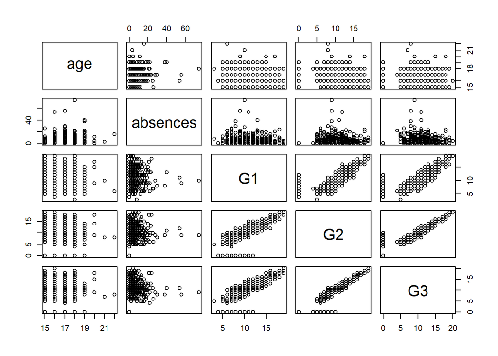

```r
#Scatter plot between different features
pairs(student_math[c("age", "absences", "G1", "G2", "G3")])
```

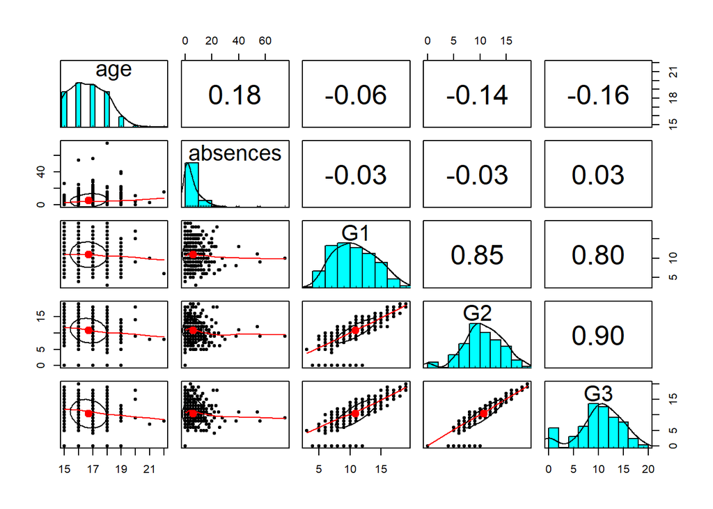

```r
#Pair.panel function is used to plot histogram and it provides correlation between different features
pairs.panels(student_math[c("age", "absences", "G1", "G2", "G3")])
```

```r
#Exploratory analysis of student_math data
summary(student_math)
```

```
##  school   sex          age       address famsize   Pstatus      Medu
##  GP:349   F:208   Min.   :15.0   R: 88   GT3:281   A: 41   Min.   :0.000
##  MS: 46   M:187   1st Qu.:16.0   U:307   LE3:114   T:354   1st Qu.:2.000
##                   Median :17.0                             Median :3.000
##                   Mean   :16.7                             Mean   :2.749
##                   3rd Qu.:18.0                             3rd Qu.:4.000
##                   Max.   :22.0                             Max.   :4.000
##       Fedu             Mjob           Fjob            reason      guardian
##  Min.   :0.000   at_home : 59   at_home : 20   course    :145   father: 90
##  1st Qu.:2.000   health  : 34   health  : 18   home      :109   mother:273
##  Median :2.000   other   :141   other   :217   other     : 36   other : 32
##  Mean   :2.522   services:103   services:111   reputation:105
##  3rd Qu.:3.000   teacher : 58   teacher : 29
##  Max.   :4.000
##    traveltime      studytime        failures      schoolsup famsup     paid
##  Min.   :1.000   Min.   :1.000   Min.   :0.0000   no :344   no :153   no :214
##  1st Qu.:1.000   1st Qu.:1.000   1st Qu.:0.0000   yes: 51   yes:242   yes:181
##  Median :1.000   Median :2.000   Median :0.0000
##  Mean   :1.448   Mean   :2.035   Mean   :0.3342
##  3rd Qu.:2.000   3rd Qu.:2.000   3rd Qu.:0.0000
##  Max.   :4.000   Max.   :4.000   Max.   :3.0000
##  activities nursery   higher    internet  romantic      famrel
##  no :194    no : 81   no : 20   no : 66   no :263   Min.   :1.000
##  yes:201    yes:314   yes:375   yes:329   yes:132   1st Qu.:4.000
##                                                     Median :4.000
##                                                     Mean   :3.944
##                                                     3rd Qu.:5.000
##                                                     Max.   :5.000
##     freetime         goout            Dalc            Walc
##  Min.   :1.000   Min.   :1.000   Min.   :1.000   Min.   :1.000
##  1st Qu.:3.000   1st Qu.:2.000   1st Qu.:1.000   1st Qu.:1.000
##  Median :3.000   Median :3.000   Median :1.000   Median :2.000
##  Mean   :3.235   Mean   :3.109   Mean   :1.481   Mean   :2.291
##  3rd Qu.:4.000   3rd Qu.:4.000   3rd Qu.:2.000   3rd Qu.:3.000
##  Max.   :5.000   Max.   :5.000   Max.   :5.000   Max.   :5.000
##      health         absences            G1              G2
##  Min.   :1.000   Min.   : 0.000   Min.   : 3.00   Min.   : 0.00
##  1st Qu.:3.000   1st Qu.: 0.000   1st Qu.: 8.00   1st Qu.: 9.00
##  Median :4.000   Median : 4.000   Median :11.00   Median :11.00
##  Mean   :3.554   Mean   : 5.709   Mean   :10.91   Mean   :10.71
##  3rd Qu.:5.000   3rd Qu.: 8.000   3rd Qu.:13.00   3rd Qu.:13.00
##  Max.   :5.000   Max.   :75.000   Max.   :19.00   Max.   :19.00
##        G3
##  Min.   : 0.00
##  1st Qu.: 8.00
##  Median :11.00
##  Mean   :10.42
##  3rd Qu.:14.00
##  Max.   :20.00
```

```r
#Selecting relevant features
math_features <- student_math[,c(2,14,16,17,18,23,24,25,29,30,31,32,33)]

#Converting categorical variables to dummy codes using factor
math_features$sex <- as.factor(math_features$sex)
math_features$schoolsup <- as.factor(math_features$schoolsup)
math_features$famsup <- as.factor(math_features$famsup)
math_features$paid <- as.factor(math_features$paid)
math_features$romantic <- as.factor(math_features$romantic)

#Multiple regression model using lm() function. Observed R-squared values is 0.8356
#and we see that the p-values is quite low
math_g3_pred <- lm(G3~sex+studytime+schoolsup+famsup+paid+romantic+famrel+freetime+health+absences+G1+G2, data = math_features)
summary(math_g3_pred)
```

```
##
## Call:
## lm(formula = G3 ~ sex + studytime + schoolsup + famsup + paid +
##     romantic + famrel + freetime + health + absences + G1 + G2,
##     data = math_features)
##
## Residuals:
##     Min      1Q  Median      3Q     Max
## -9.3194 -0.4608  0.2894  0.9535  3.8932
##
## Coefficients:
##              Estimate Std. Error t value Pr(>|t|)
## (Intercept)  -3.71833    0.69456  -5.353 1.49e-07 ***
## sexM          0.10543    0.21213   0.497  0.61948
## studytime    -0.15404    0.12436  -1.239  0.21624
## schoolsupyes  0.51095    0.29741   1.718  0.08661 .
## famsupyes     0.14637    0.20887   0.701  0.48388
## paidyes       0.15748    0.20482   0.769  0.44244
## romanticyes  -0.36712    0.20874  -1.759  0.07942 .
## famrel        0.31208    0.10856   2.875  0.00427 **
## freetime      0.04278    0.09988   0.428  0.66864
## health        0.07095    0.07015   1.011  0.31242
## absences      0.04072    0.01212   3.359  0.00086 ***
## G1            0.18574    0.05720   3.247  0.00127 **
## G2            0.97181    0.05002  19.430  < 2e-16 ***
## ---
## Signif. codes:  0 '***' 0.001 '**' 0.01 '*' 0.05 '.' 0.1 ' ' 1
##
## Residual standard error: 1.887 on 382 degrees of freedom
## Multiple R-squared:  0.8356, Adjusted R-squared:  0.8304
## F-statistic: 161.8 on 12 and 382 DF,  p-value: < 2.2e-16
```

```r
#Using backward step elimination method to remove non-significant features.
#We see that out of 12 features 6 have been removed because of low AIC
step(math_g3_pred, direction = "backward")
```

```
## Start:  AIC=514.3
## G3 ~ sex + studytime + schoolsup + famsup + paid + romantic +
##     famrel + freetime + health + absences + G1 + G2
##
##             Df Sum of Sq    RSS    AIC
## - freetime   1      0.65 1360.5 512.49
## - sex        1      0.88 1360.7 512.56
## - famsup     1      1.75 1361.5 512.81
## - paid       1      2.10 1361.9 512.91
## - health     1      3.64 1363.4 513.36
## - studytime  1      5.46 1365.3 513.89
## <none>                   1359.8 514.30
## - schoolsup  1     10.51 1370.3 515.34
## - romantic   1     11.01 1370.8 515.49
## - famrel     1     29.42 1389.2 520.76
## - G1         1     37.54 1397.3 523.06
## - absences   1     40.17 1400.0 523.80
## - G2         1   1343.89 2703.7 783.78
##
## Step:  AIC=512.49
## G3 ~ sex + studytime + schoolsup + famsup + paid + romantic +
##     famrel + health + absences + G1 + G2
##
##             Df Sum of Sq    RSS    AIC
## - sex        1      1.24 1361.7 510.85
## - famsup     1      1.91 1362.4 511.05
## - paid       1      2.02 1362.5 511.08
## - health     1      3.70 1364.2 511.56
## - studytime  1      5.86 1366.3 512.19
## <none>                   1360.5 512.49
## - schoolsup  1     10.45 1370.9 513.51
## - romantic   1     10.89 1371.3 513.64
## - famrel     1     31.32 1391.8 519.48
## - G1         1     37.92 1398.4 521.35
## - absences   1     39.76 1400.2 521.87
## - G2         1   1343.41 2703.9 781.80
##
## Step:  AIC=510.85
## G3 ~ studytime + schoolsup + famsup + paid + romantic + famrel +
##     health + absences + G1 + G2
```

[output cut: 55 more lines]

```
## - G1         1     35.92 1406.8 515.73
## - absences   1     38.99 1409.9 516.60
## - G2         1   1391.78 2762.7 782.30
##
## Step:  AIC=507.5
## G3 ~ schoolsup + romantic + famrel + absences + G1 + G2
##
##             Df Sum of Sq    RSS    AIC
## <none>                   1377.8 507.50
## - schoolsup  1      8.47 1386.3 507.92
## - romantic   1     12.50 1390.3 509.07
## - famrel     1     33.35 1411.2 514.95
## - G1         1     33.41 1411.2 514.97
## - absences   1     41.53 1419.3 517.23
## - G2         1   1391.35 2769.2 781.23
```

```
##
## Call:
## lm(formula = G3 ~ schoolsup + romantic + famrel + absences +
##     G1 + G2, data = math_features)
##
## Coefficients:
##  (Intercept)  schoolsupyes   romanticyes        famrel      absences
##     -3.37474       0.45186      -0.38852       0.32649       0.04111
##           G1            G2
##      0.17304       0.97548
```

```r
#Testing multiple regression model for new selected features.
#We observe that the R-squared values has reduced from 0.8356 to 0.8334 but the p-value remains the same.
new_math_g3_pred <- lm(G3~schoolsup+romantic+famrel+absences+G1+G2, data = math_features)
summary(new_math_g3_pred)
```

```
##
## Call:
## lm(formula = G3 ~ schoolsup + romantic + famrel + absences +
##     G1 + G2, data = math_features)
##
## Residuals:
##     Min      1Q  Median      3Q     Max
## -9.4165 -0.3955  0.2811  0.9153  3.5797
##
## Coefficients:
##              Estimate Std. Error t value Pr(>|t|)
## (Intercept)  -3.37474    0.55390  -6.093 2.68e-09 ***
## schoolsupyes  0.45186    0.29257   1.544 0.123293
## romanticyes  -0.38852    0.20705  -1.876 0.061349 .
## famrel        0.32649    0.10654   3.065 0.002332 **
## absences      0.04111    0.01202   3.420 0.000693 ***
## G1            0.17304    0.05642   3.067 0.002312 **
## G2            0.97548    0.04928  19.794  < 2e-16 ***
## ---
## Signif. codes:  0 '***' 0.001 '**' 0.01 '*' 0.05 '.' 0.1 ' ' 1
##
## Residual standard error: 1.884 on 388 degrees of freedom
## Multiple R-squared:  0.8334, Adjusted R-squared:  0.8308
## F-statistic: 323.5 on 6 and 388 DF,  p-value: < 2.2e-16
```

```r
#As we observed in the above model that the residual standard error is 1.884,
#we assign this to a new variable
SE <- 1.884

#We select a test data for prediction
sample_data_CI <- student_math[395,]
sample_data_CI
```

|  | school | sex | age | address | famsize | Pstatus | Medu | Fedu | Mjob | Fjob | reason | guardian | traveltime | studytime | failures | schoolsup | famsup | paid | activities | nursery | higher | internet | romantic | famrel | freetime | goout | Dalc | Walc | health | … |
| --- | --- | --- | --- | --- | --- | --- | --- | --- | --- | --- | --- | --- | --- | --- | --- | --- | --- | --- | --- | --- | --- | --- | --- | --- | --- | --- | --- | --- | --- | --- |
| 395 | MS | M | 19 | U | LE3 | T | 1 | 1 | other | at_home | course | father | 1 | 1 | 0 | no | no | no | no | yes | yes | yes | no | 3 | 2 | 3 | 3 | 3 | 5 | … |

```r
#Using test sample to predict the G3 grade for row 395
CI_pred <- predict(new_math_g3_pred, sample_data_CI)

#Calculating upper and lower boundary for 95% confidence interval
lower_CI <- unname(CI_pred - (1.96 * SE))
upper_CI <- unname(CI_pred + (1.96 * SE))

#As we can see that predicted value lies in between the upper and
#lower boundaries of 95% confidence interval
CI_pred
```

```
##      395
## 7.973976
```

```r
lower_CI
```

```
## [1] 4.281336
```

```r
upper_CI
```

```
## [1] 11.66662
```

```r
#Calculating RMSE value for whole data.
#We use residual function to get the error values.
model <- lm(G3~., data = student_math)

RMSE <- sqrt(mean(model$residuals^2))
RMSE
```

```
## [1] 1.796979
```

Problem 2 : For this problem, the following short tutorial might be helpful in interpreting the logistic regression output.

1. Using the same data set as in Problem (1), add another column, PF – pass-fail. Mark any student whose final grade is less than 10 as F, otherwise as P and then build a dummy code variable for that new column. Use the new dummy variable column as the response variable.
2. Build a binomial logistic regression model classifying a student as passing or failing. Eliminate any non-significant variable using an elimination approach of your choice. Use as many features as you like but you must use at least four – choose the ones you believe are most useful.
3. State the regression equation.
4. What is the accuracy of your model? Use the entire data set for both training and validation.

```r
#Creating a duplicate of student_math dataset
student_math_PF <- student_math

#Creating a new column of pass and fail
student_math_PF$PF <- ifelse(student_math_PF$G3 < 10, "F", "P")

#Converting the categorical variable to dummy code using as.factor() function
student_math_PF$PF <- as.factor(student_math_PF$PF)

#Exploring new data
head(student_math_PF)
```

|  | school | sex | age | address | famsize | Pstatus | Medu | Fedu | Mjob | Fjob | reason | guardian | traveltime | studytime | failures | schoolsup | famsup | paid | activities | nursery | higher | internet | romantic | famrel | freetime | goout | Dalc | Walc | health | … |
| --- | --- | --- | --- | --- | --- | --- | --- | --- | --- | --- | --- | --- | --- | --- | --- | --- | --- | --- | --- | --- | --- | --- | --- | --- | --- | --- | --- | --- | --- | --- |
| 1 | GP | F | 18 | U | GT3 | A | 4 | 4 | at_home | teacher | course | mother | 2 | 2 | 0 | yes | no | no | no | yes | yes | no | no | 4 | 3 | 4 | 1 | 1 | 3 | … |
| 2 | GP | F | 17 | U | GT3 | T | 1 | 1 | at_home | other | course | father | 1 | 2 | 0 | no | yes | no | no | no | yes | yes | no | 5 | 3 | 3 | 1 | 1 | 3 | … |
| 3 | GP | F | 15 | U | LE3 | T | 1 | 1 | at_home | other | other | mother | 1 | 2 | 3 | yes | no | yes | no | yes | yes | yes | no | 4 | 3 | 2 | 2 | 3 | 3 | … |
| 4 | GP | F | 15 | U | GT3 | T | 4 | 2 | health | services | home | mother | 1 | 3 | 0 | no | yes | yes | yes | yes | yes | yes | yes | 3 | 2 | 2 | 1 | 1 | 5 | … |
| 5 | GP | F | 16 | U | GT3 | T | 3 | 3 | other | other | home | father | 1 | 2 | 0 | no | yes | yes | no | yes | yes | no | no | 4 | 3 | 2 | 1 | 2 | 5 | … |
| 6 | GP | M | 16 | U | LE3 | T | 4 | 3 | services | other | reputation | mother | 1 | 2 | 0 | no | yes | yes | yes | yes | yes | yes | no | 5 | 4 | 2 | 1 | 2 | 5 | … |

```r
#Counting total elements in PF column
table(student_math_PF$PF)
```

```
##
##   F   P
## 130 265
```

```r
#Binomial logistic regression of pass or fail using selected relevant features
glm_pred <- glm(PF~sex+studytime+schoolsup+famsup+paid+romantic+famrel+freetime+health+absences+G1+G2, data=student_math_PF, family="binomial")

#We observe that the AIC of the model is 153.92
summary(glm_pred)
```

```
##
## Call:
## glm(formula = PF ~ sex + studytime + schoolsup + famsup + paid +
##     romantic + famrel + freetime + health + absences + G1 + G2,
##     family = "binomial", data = student_math_PF)
##
## Deviance Residuals:
##      Min        1Q    Median        3Q       Max
## -2.88309  -0.02830   0.00328   0.13082   2.36556
##
## Coefficients:
##               Estimate Std. Error z value Pr(>|z|)
## (Intercept)  -20.16349    3.27547  -6.156 7.47e-10 ***
## sexM          -0.39261    0.52814  -0.743  0.45725
## studytime     -0.89826    0.34539  -2.601  0.00930 **
## schoolsupyes   0.02781    0.59438   0.047  0.96268
## famsupyes     -0.39508    0.50775  -0.778  0.43651
## paidyes        0.08593    0.49225   0.175  0.86142
## romanticyes   -0.74386    0.52499  -1.417  0.15651
## famrel         0.85086    0.31590   2.693  0.00707 **
## freetime      -0.15098    0.25705  -0.587  0.55696
## health        -0.20115    0.17196  -1.170  0.24211
## absences      -0.03572    0.02704  -1.321  0.18654
## G1             0.25958    0.17212   1.508  0.13151
## G2             1.99651    0.32051   6.229 4.69e-10 ***
## ---
## Signif. codes:  0 '***' 0.001 '**' 0.01 '*' 0.05 '.' 0.1 ' ' 1
##
## (Dispersion parameter for binomial family taken to be 1)
##
##     Null deviance: 500.50  on 394  degrees of freedom
## Residual deviance: 127.92  on 382  degrees of freedom
## AIC: 153.92
##
## Number of Fisher Scoring iterations: 8
```

```r
#Using backward elimination method to remove irrelevant features.
#We observe that out of 12 features we are left with 4 significant features
step(glm_pred, direction="backward")
```

```
## Start:  AIC=153.92
## PF ~ sex + studytime + schoolsup + famsup + paid + romantic +
##     famrel + freetime + health + absences + G1 + G2
##
##             Df Deviance    AIC
## - schoolsup  1   127.92 151.92
## - paid       1   127.95 151.95
## - freetime   1   128.27 152.27
## - sex        1   128.48 152.48
## - famsup     1   128.53 152.53
## - health     1   129.31 153.31
## <none>           127.92 153.92
## - romantic   1   129.96 153.96
## - absences   1   130.04 154.04
## - G1         1   130.30 154.30
## - studytime  1   135.44 159.44
## - famrel     1   136.06 160.06
## - G2         1   231.87 255.87
##
## Step:  AIC=151.92
## PF ~ sex + studytime + famsup + paid + romantic + famrel + freetime +
##     health + absences + G1 + G2
##
##             Df Deviance    AIC
## - paid       1   127.95 149.95
## - freetime   1   128.27 150.27
## - sex        1   128.48 150.48
## - famsup     1   128.54 150.54
## - health     1   129.35 151.35
## <none>           127.92 151.92
## - romantic   1   130.02 152.02
## - absences   1   130.06 152.06
## - G1         1   130.34 152.34
## - studytime  1   135.53 157.53
## - famrel     1   136.19 158.19
## - G2         1   233.31 255.31
##
## Step:  AIC=149.95
## PF ~ sex + studytime + famsup + romantic + famrel + freetime +
##     health + absences + G1 + G2
```

[output cut: 76 more lines]

```
## <none>           132.86 144.86
## - romantic   1   136.64 146.64
## - studytime  1   138.11 148.11
## - famrel     1   141.06 151.06
## - G2         1   243.62 253.62
##
## Step:  AIC=144.68
## PF ~ studytime + romantic + famrel + G2
##
##             Df Deviance    AIC
## <none>           134.68 144.68
## - romantic   1   137.85 145.85
## - studytime  1   139.37 147.37
## - famrel     1   143.53 151.53
## - G2         1   493.61 501.61
```

```
##
## Call:  glm(formula = PF ~ studytime + romantic + famrel + G2, family = "binomial",
##     data = student_math_PF)
##
## Coefficients:
## (Intercept)    studytime  romanticyes       famrel           G2
##    -21.2057      -0.6036      -0.8220       0.8104       2.1259
##
## Degrees of Freedom: 394 Total (i.e. Null);  390 Residual
## Null Deviance:       500.5
## Residual Deviance: 134.7     AIC: 144.7
```

```r
#Testing model with new features
glm_pred_new <- glm(PF~studytime+romantic+famrel+G2, data=student_math_PF, family="binomial")

#We see that AIC has reduced to 144.68 from 153.92
summary(glm_pred_new)
```

```
##
## Call:
## glm(formula = PF ~ studytime + romantic + famrel + G2, family = "binomial",
##     data = student_math_PF)
##
## Deviance Residuals:
##      Min        1Q    Median        3Q       Max
## -2.90805  -0.03616   0.00473   0.12694   2.37845
##
## Coefficients:
##             Estimate Std. Error z value Pr(>|z|)
## (Intercept) -21.2057     3.1221  -6.792 1.11e-11 ***
## studytime    -0.6036     0.2883  -2.093  0.03632 *
## romanticyes  -0.8220     0.4665  -1.762  0.07809 .
## famrel        0.8104     0.2892   2.803  0.00507 **
## G2            2.1259     0.2903   7.322 2.43e-13 ***
## ---
## Signif. codes:  0 '***' 0.001 '**' 0.01 '*' 0.05 '.' 0.1 ' ' 1
##
## (Dispersion parameter for binomial family taken to be 1)
##
##     Null deviance: 500.50  on 394  degrees of freedom
## Residual deviance: 134.68  on 390  degrees of freedom
## AIC: 144.68
##
## Number of Fisher Scoring iterations: 8
```